# Regularity Conditions for Consistency of Jeffreys Approximate Objective Bayes Factor in Seven or More Experiments

============================================================================================================

Open Science Framework: https://osf.io/qeprj/

## 1. Introduction

To test the hypotheses $\mathcal{H}_0:\boldsymbol{\theta}=\boldsymbol{\theta}_0$ versus $\mathcal{H}_1:\boldsymbol{\theta}\neq\boldsymbol{\theta}_0$, we define the extended Jeffreys approximate objective Bayes factor (eJAB) in Eq. 1.
$$\begin{equation} \tag{1}
\mathit{eJAB}_{01}=\sqrt{N}\exp\left\{-\frac{1}{2}\frac{N^{1/q}-1}{N^{1/q}}\cdot
Q_{\chi^{2}_{q}}(1-p)\right\},
\end{equation}$$

where $q$ is the size of the parameter vector $\boldsymbol{\theta}$, $N$ is the sample size, $Q_{\chi^{2}_{q}}(\cdot)$ is the quantile function of the chi-squared distribution with $q$ degrees of freedom, and $p$ is the $p$-value from a null-hypothesis significance test. We further define $\mathit{eJAB}_{10}=1\ \!/\ \!\mathit{eJAB}_{01}$.

The sample size $N$ is

- the total number of observations for for $t$-tests, linear regression, logistic regression, one-way ANOVA, and chi-squared tests.
- the number of events for Cox models.
- the number of independent observations for one-way repeated-measures ANOVA (Nathoo & Masson, [2016](https://dx.doi.org/10.1016/j.jmp.2015.03.003)).

The degrees of freedom are

- $q=1$ for $t$-tests, linear regression, logistic regression, and Cox models, where $\mathcal{H}_0$ specifies a point-null hypothesis (Wagenmakers, [2022](https://doi.org/10.31234/osf.io/egydq)).
- $q=I-1$ for one-way ANOVA and one-way repeated-measures ANOVA, where $I$ is the number of conditions.
- $q=(R-1)(C-1)$ for chi-squared tests, where $R$ and $C$ are the numbers of rows and columns, respectively.

Since the Bayes factor is the ratio of the marginal likelihoods of two competing models, $q=p_1-p_0$ also represents the difference in the number of free parameters between the alternative and null models. We will discuss the hypotheses and model specifications in Examples below and Section 5, particularly when $q>1$.

### Derivation

The Savage–Dickey density ratio is a special form of the Bayes factor for nested models by dividing the value of  
the posterior density over the parameters for the alternative model evaluated at the hypothesized value by  
the prior for the same model evaluated at the same point.

$$\begin{equation} \tag{2}
\textit{BF}_{01}:=\frac{p(\boldsymbol{y}\mid
\mathcal{H}_0)}{p(\boldsymbol{y}\mid
\mathcal{H}_1)}=\frac{\color{#0055A4}{p(\boldsymbol{\theta}=\boldsymbol{\theta}_0\mid\boldsymbol{y},\mathcal{H}_1)}}{\color{#EF4135}{p(\boldsymbol{\theta}=\boldsymbol{\theta}_0\mid
\mathcal{H}_1)}}
\end{equation}$$

Under standard regularity conditions and with a large sample size $N$, we can approximate $p(\boldsymbol{\theta}\mid\boldsymbol{y},\mathcal{H}_1)$ as a multivariate Gaussian distribution centered at the maximum likelihood estimate (MLE) $\hat{\boldsymbol{\theta}}$, with the observed Fisher information matrix $\left[\ I(\hat{\boldsymbol{\theta}})\ \right]_{ij}$ serving as the precision matrix (i.e., the inverse of the covariance matrix). $\lvert\ \!\cdot\ \!\rvert$ denotes the determinant. Thus,

$$\begin{equation} \tag{3}
p(\boldsymbol{\theta}=\boldsymbol{\theta}_0\mid\boldsymbol{y},\mathcal{H}_1)\approx(2\pi)^{-\frac{q}{2}}\cdot\lvert
I(\hat{\boldsymbol{\theta}})\rvert^{\frac{1}{2}}\cdot\exp{\left\{-\frac{1}{2}(\boldsymbol{\theta}_0-\hat{\boldsymbol{\theta}})^\top\cdot
I(\hat{\boldsymbol{\theta}})\cdot(\boldsymbol{\theta}_0-\hat{\boldsymbol{\theta}})\right\}}
\end{equation}$$

Next, we assume the prior $\boldsymbol{\theta}\sim\boldsymbol{\mathcal{N}}_q\!\left(\hat{\boldsymbol{\theta}},\ N^{1/q}\cdot I^{-1}(\hat{\boldsymbol{\theta}})\right)$, which, for $q=1$, corresponds to the normal unit-information prior. For $q>1$, the prior becomes more informative, placing more weight on the MLE.

$$\begin{equation} \tag{4}
p(\boldsymbol{\theta}=\boldsymbol{\theta}_0\mid
\mathcal{H}_1)=(2\pi)^{-\frac{q}{2}}\cdot N^{-\frac{1}{2}}\cdot\lvert
I(\hat{\boldsymbol{\theta}})\rvert^{\frac{1}{2}}\cdot\exp{\left\{-\frac{1}{2N^{1/q}}(\boldsymbol{\theta}_0-\hat{\boldsymbol{\theta}})^\top\cdot
I(\hat{\boldsymbol{\theta}})\cdot(\boldsymbol{\theta}_0-\hat{\boldsymbol{\theta}})\right\}}
\end{equation}$$

The Wald test statistic is $W_N=(\boldsymbol{\theta}_0-\hat{\boldsymbol{\theta}})^\top\cdot I(\hat{\boldsymbol{\theta}})\cdot(\boldsymbol{\theta}_0-\hat{\boldsymbol{\theta}})\mathrel{\dot\sim}\chi_{q}^2\$ under $\mathcal{H}_0$.

Plugging Eq. 3 and 4 into Eq. 2, we obtain the following $\mathit{eJAB}_{01}$ expression.

$$\begin{align}
\mathit{eJAB}_{01}&=\frac{p(\boldsymbol{\theta}=\boldsymbol{\theta}_0\mid\boldsymbol{y},\mathcal{H}_1)}{p(\boldsymbol{\theta}=\boldsymbol{\theta}_0\mid
\mathcal{H}_1)} \\
&=\sqrt{N}\exp\left\{-\frac{1}{2}\frac{N^{1/q}-1}{N^{1/q}}\cdot
(\boldsymbol{\theta}_0-\hat{\boldsymbol{\theta}})^\top\cdot
I(\hat{\boldsymbol{\theta}})\cdot(\boldsymbol{\theta}_0-\hat{\boldsymbol{\theta}})\right\}
\\
&=\sqrt{N}\exp\left\{-\frac{1}{2}\frac{N^{1/q}-1}{N^{1/q}}\cdot
W_N\right\} \\
&=\sqrt{N}\exp\left\{-\frac{1}{2}\frac{N^{1/q}-1}{N^{1/q}}\cdot
Q_{\chi^{2}_{q}}(1-p)\right\}
\end{align}$$

scroll to top

### Remarks

If, instead of a Wald test, the $p$-value is from a likelihood ratio test, then $Q_{\chi^{2}_{q}}(1-p)=\Lambda:=-2(\ln{\mathcal{L}_0}-\ln{\mathcal{L}_1})$.

$\mathcal{L}_i=p(\boldsymbol{y}\mid\hat{\boldsymbol{\theta}}_i,\mathcal{M}_i)$ is the maximum likelihood, given model $i$ and $N\gg p_i$.

$$\begin{align}
\text{BIC}(\mathcal{M}_1)-\text{BIC}(\mathcal{M}_0)&=-2\ln{\mathcal{L}_1}+p_1\ln{N}+2\ln{\mathcal{L}_0}-p_0\ln{N}
\\
&=-2(\ln{\mathcal{L}_1}-\ln{\mathcal{L}_0})+(p_1-p_0)\ln{N} \\
&=-\Lambda+q\ln{N} \\
\\
\mathit{BF}_{01}&\approx\exp\left\{\frac{\text{BIC}(\mathcal{M}_1)-\text{BIC}(\mathcal{M}_0)}{2}\right\}
\\
&=\exp\left\{\frac{-\Lambda+q\ln{N}}{2}\right\} \\
&=N^{\frac{q}{2}}\exp\left\{-\frac{1}{2}\cdot
Q_{\chi^{2}_{q}}(1-p)\right\} \tag{5}
\end{align}$$

For $q=1$ and large $N$, Eq. 1 is asymptotically equivalent to the BIC approximation of the Bayes factor in Eq. 5.

> Assumptions

We observe that $\mathit{eJAB}_{01}$ arises from the following assumptions:

- The Savage–Dickey density ratio representation of the Bayes factor holds (Wagenmakers et al., [2010](https://doi.org/10.1016/j.cogpsych.2009.12.001); Heck, [2019](https://doi.org/10.1111/bmsp.12150)).
- The posterior density is normal, centered at the MLE with precision given by the observed Fisher information. This assumption is justified by the Bayesian central limit theorem under standard regularity conditions.
- A modified unit information prior is a normal distribution centered at the MLE, with precision given by the observed Fisher information divided by the $q$-th root of the sample size. The objective is to reduce the bias towards the null hypothesis (Section 6).
- $\frac{N^{1/q}-1}{N^{1/q}}\approx1$. Though for small samples, it is advisable to retain the term.

We will further examine the $p$-values from:

- A nonparametric test
- A one-sided test
- Multiple comparisons
- Testing random effects (as opposed to fixed effects)

scroll to top

### Example: Two-Way ANOVA

In a two-way ANOVA, we compare an additive model, $\mathcal{M}_{\text{add}}$, to a model, $\mathcal{M}_{\text{omitA}}$, which omits the factor being tested, suppose factor $A$, in testing $\mathcal{H}_0:\alpha_i=0$ versus $\mathcal{H}_1:$ at least one $\alpha_i\neq0$.

$$\begin{align}
\mathcal{M}_{\text{full}}:\
Y_{ijk}&=\mu+\alpha_i+\beta_j+(\alpha\beta)_{ij}+\epsilon_{ijk} \\
\mathcal{M}_{\text{add}}:\
Y_{ijk}&=\mu+\alpha_i+\beta_j+\epsilon_{ijk} \\
\mathcal{M}_{\text{omitA}}:\ Y_{ijk}&=\mu+\beta_j+\epsilon_{ijk}
\\
\mathcal{M}_{\text{omitB}}:\
Y_{ijk}&=\mu+\alpha_i+\epsilon_{ijk},\qquad\epsilon_{ijk}\overset{\text{i.i.d.}}{\sim}\mathcal{N}(0,\
\sigma_\epsilon^2) \\
&\qquad\text{for}\ i=1,\dotsb,I;\ j=1,\dotsb,J;\ \text{and}\
k=1,\dotsb,K\neq1
\end{align}$$

The sum-to-zero constraints impose that $\sum_{i=1}^I\alpha_i=0$, $\sum_{j=1}^J\beta_j=0$, and $\sum_{i=1}^I(\alpha\beta)_{ij}=\sum_{j=1}^J(\alpha\beta)_{ij}=0$.

The number of free parameters in $\mathcal{M}_{\text{add}}$ is given by $p_1=1+(I-1)+(J-1)+1=I+J$.

The number of free parameters in $\mathcal{M}_{\text{omitA}}$ is given by $p_0=1+(J-1)+1=J+1$.

Thus, the difference in free parameters is $q=p_1-p_0=I-1$, which is equivalent to the number of free parameters in a one-way ANOVA.

The sample size in this case is $N=IJK$.

```r
ToothGrowth$dose <- factor(ToothGrowth$dose)

fit_full <- aov(len ~ supp * dose, ToothGrowth) # 2×3 (between-subjects) ANOVA
summary(fit_full) # full model  <== significant interaction
```

```
##             Df Sum Sq Mean Sq F value   Pr(>F)
## supp         1  205.3   205.3  15.572 0.000231 ***
## dose         2 2426.4  1213.2  92.000  < 2e-16 ***
## supp:dose    2  108.3    54.2   4.107 0.021860 *
## Residuals   54  712.1    13.2
## ---
## Signif. codes:  0 '***' 0.001 '**' 0.01 '*' 0.05 '.' 0.1 ' ' 1
```

```r
fit_full <- aov(len ~ supp + dose, ToothGrowth)
summary(fit_full) # additive model
```

```
##             Df Sum Sq Mean Sq F value   Pr(>F)
## supp         1  205.3   205.3   14.02 0.000429 ***
## dose         2 2426.4  1213.2   82.81  < 2e-16 ***
## Residuals   56  820.4    14.7
## ---
## Signif. codes:  0 '***' 0.001 '**' 0.01 '*' 0.05 '.' 0.1 ' ' 1
```

```r
fit_add <- lm(len ~ supp + dose, ToothGrowth)
fit_omitSupp <- lm(len ~ dose, ToothGrowth)
anova(fit_add, fit_omitSupp) # testing the main effect `supp`
```

```
## Analysis of Variance Table
##
## Model 1: len ~ supp + dose
## Model 2: len ~ dose
##   Res.Df     RSS Df Sum of Sq      F    Pr(>F)
## 1     56  820.43
## 2     57 1025.78 -1   -205.35 14.017 0.0004293 ***
## ---
## Signif. codes:  0 '***' 0.001 '**' 0.01 '*' 0.05 '.' 0.1 ' ' 1
```

scroll to top

### Example: Contingency Table

The chi-squared test for independence examines whether two categorical variables are independent. Under the null hypothesis of independence, the expected frequency $\mu_{ij}$ in each cell of a contingency table is calculated based on the assumption that the joint probability $\pi_{ij}$ equals the product of the marginal probabilities $\pi_{i\cdot}$ and $\pi_{\cdot j}$

The numbers of parameters are $p_1=R\cdot C-1$ under $\mathcal{H}_1$ and $p_0=R+C-2$ under $\mathcal{H}_0$, assuming a fixed total and a joint multinomial distribution. And the numbers of parameters are $p_1=R\cdot(C-1)$ under $\mathcal{H}_1$ and $p_0=C-1$ under $\mathcal{H}_0$, assuming fixed row sums and independent multinomial distributions.

$q=p_1-p_0=(R-1)(C-1)$

$$\begin{align}
Y_{ij}&\overset{\text{ind.}}{\sim}\operatorname{Pois}(\mu_{ij}) \\
\ln{\mu_{ij}}&=\mu+\alpha_i+\beta_j+(\alpha\beta)_{ij}\qquad\text{for}\
i=1,\dotsb,R\ \text{and}\ j=1,\dotsb,C
\end{align}$$

Alternatively, using [log-linear models](https://www.ma.imperial.ac.uk/~das01/MyWeb/M3S12/Handouts/Notes/Chap6.pdf), the null hypothesis of independence can be expressed by setting the interaction terms to zero, $\mathcal{H}_0:(\alpha\beta)_{ij}=0$.

scroll to top

## 2. Lemma

> Lemma

For $x\to1^-$,
$$\begin{equation} \tag{6}
g(x)=-2\ln(1-x)-2\ln(-\ln(1-x))-Q_{\chi^{2}_{1}}(x)<0
\end{equation}$$

*Proof:*

Let $F_{\chi_1^2}(x)=2\Phi(\sqrt{x})-1$ for $x>0$, where $\Phi(x)$ denotes the cumulative distribution function of the standard normal distribution. Then, the probability density function is $f_{\chi_1^2}(x):=F_{\chi_1^2}^\prime(x)=\varphi(\sqrt{x})\ /\ \sqrt{x}=\frac{1}{\sqrt{2\pi x}}\cdot\exp\{-x/2\}$, where $\varphi(x)=\Phi^\prime(x)$.

The quantile function $Q_{\chi^{2}_{1}}(x):=F_{\chi_1^2}^{-1}(x)$—and therefore $g(x)$—is continuous on the domain $(0,1)$.

Using the [inverse function rule](https://en.wikipedia.org/wiki/Inverse_function_rule), $Q_{\chi_1^2}^\prime(x)=\left(F_{\chi_1^2}^{-1}(x)\right)^\prime=\frac{1}{F_{\chi_1^2}^\prime\ \!(F_{\chi_1^2}^{-1}(x))}=\frac{1}{f_{\chi_1^2}\ \!(Q_{\chi_1^2}(x))}=\sqrt{2\pi Q_{\chi_1^2}(x)}\cdot\exp\left\{ Q_{\chi_1^2}(x)\ \!/\ \! 2 \right\}>0$.

$$\begin{align}
g^\prime(x)&=\frac{2+2\ln{(1-x)}}{(1-x)\ln{(1-x)}}-\sqrt{2\pi
Q_{\chi^{2}_{1}}(x)}\cdot\exp\left\{Q_{\chi^{2}_{1}}(x)\ /\ 2\right\} \\
&<\frac{2+2\ln{(1-x)}}{(1-x)\ln{(1-x)}}=\frac{2-2\left(\sum_{m=1}^\infty\frac{x^m}{m}\right)}{(1-x)\ln{(1-x)}}
\\
&<\frac{2-2x}{(1-x)\ln{(1-x)}}=\frac{2}{\ln{(1-x)}}<0
\end{align}$$

$g^\prime(x)<0$ implies that $g(x)$ is a monotonically decreasing function.

We note that $g(.9)>0$ and $g(.99)<0$, indicating that $g(x^*)=0$ for only one $x^*\in(.9,.99)$.

Thus, $-2\ln(1-x)-2\ln(-\ln(1-x))<Q_{\chi^{2}_{1}}(x)$ for $x^*<x<1$.

$\hspace{56em}\blacksquare$

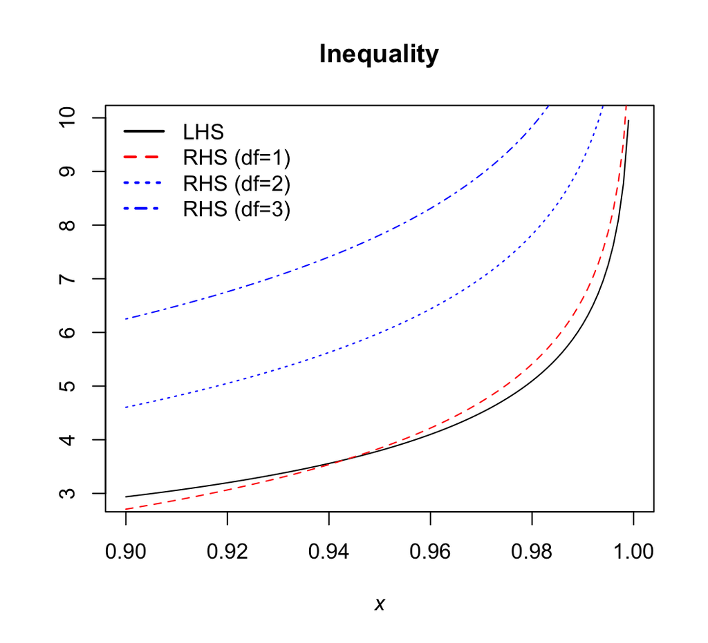

```r
curve(-2*log(1-x)-2*log(-log(1-x)), 0.9, 1,
      ylab="", xlab=expression(italic(x)), main="Inequality")
curve(qchisq(x, 1), 0.9, 1, add=T, col="red", lty=2)
curve(qchisq(x, 2), 0.9, 1, add=T, col="blue", lty=3)
curve(qchisq(x, 3), 0.9, 1, add=T, col="blue", lty=4)
legend("topleft", c("LHS", "RHS (df=1)", "RHS (df=2)", "RHS (df=3)"),
       col=c("black", "red", "blue", "blue"), lty=1:4, lwd=2, bty="n")
```

scroll to top

## 3. Regularity Conditions

> Theorem

**R1**: Assume that $p\text{-value}\overset{D}{\to}\text{Unif}(0,1)$ under $\mathcal{H}_0$.

**R2**: Assume that if $\mathcal{H}_1$ is true, then the $p$-value decreases to zero with increasing $N$ in such a way that
$$\begin{equation} \tag{7}
D_{N}=\sqrt{N}\cdot
p\text{-value}\cdot(-\ln{p\text{-value}})\overset{P}{\to}0\quad\text{as}\
N\to\infty.
\end{equation}$$

Then,
$$\begin{equation} \tag{8}
\DeclareMathOperator*{\plim}{plim}
\plim_{N\to\infty}\mathit{eJAB}_{01}=
\begin{cases}
\infty & \text{under}\ \mathcal{H}_0 \\
0 & \text{under}\ \mathcal{H}_1
\end{cases}
\end{equation}$$

Note that **R1** is weaker than the assumption that the $p$-value is distributed as $\text{Unif}(0,1)$, and it is this stronger assumption that is violated by some permutation tests.

The stronger condition for **R2** also holds:
$$\begin{align} \tag{$7^*$}
D_{N}^*&=\sqrt{N}\cdot\left(p\text{-value}\cdot(-\ln{p\text{-value}})\right)^{\frac{N^{1/q}-1}{N^{1/q}}}
\\
&=N^{\frac{1}{2N^{1/q}}}\cdot
D_N^{1-\frac{1}{N^{1/q}}}\overset{P}{\to}0,
\end{align}$$
by the continuous mapping theorem, noting that $N^{\frac{1}{2N^{1/q}}}\to1$ and $1-\frac{1}{N^{1/q}}\to1$ as $N\to\infty$.

Here, we investigate the regularity conditions **R1** and **R2** for each of the seven tests considered in our simulations.

- [Link 1](https://rpubs.com/sherloconan/1203268) two-sample $t$-test (balanced group sizes with equal variance)
- [Link 2](https://rpubs.com/sherloconan/1206246) simple linear regression
- [Link 3](https://rpubs.com/sherloconan/1206247) simple logistic regression (binomial family)
- [Link 4](https://rpubs.com/sherloconan/1208326) one-way analysis of variance (ANOVA, balanced group sizes among four groups)
- [Link 5](https://rpubs.com/sherloconan/1208327) one-way repeated-measures ANOVA (four conditions with high intraclass correlation)
- [Link 6](https://rpubs.com/sherloconan/1212352) chi-squared test for independence ($3\times3$ contingency table with a fixed total)
- [Link 7](https://rpubs.com/sherloconan/1216724) Cox proportional-hazards regression (random right-censoring)

scroll to top

## 4. Proof

*Proof:*

Case 1: Assume that $\mathcal{H}_0$ is true.

From **R1**, we have that $1-p\overset{D}{\to}\text{Unif}(0,1)$.

Then, by the continuous mapping theorem, $W_N=Q_{\chi^{2}_{q}}(1-p) \overset{D}{\to} \chi^{2}_{q}$.

Let $B>0$ and $\delta\in(0,1)$ be arbitrary. Now, for $N\geqslant N^*=\lceil B^2\exp\{Q_{\chi^{2}_{q}}(1-\delta)\}\rceil$, we have

$$\begin{align}
\mathbb{P}(\mathit{eJAB}_{01} >
B)&=\mathbb{P}\left(\sqrt{N}\exp\left\{-\frac{1}{2}\frac{N^{1/q}-1}{N^{1/q}}W_N\right\}>B\right)
>
\mathbb{P}\left(\sqrt{N}\exp\left\{-\frac{1}{2}W_N\right\}>B\right)
\\
&=\mathbb{P}\left(W_N < -2
\ln{\frac{B}{\sqrt{N}}}\right)\geqslant\mathbb{P}\left(W_N < -2
\ln{\frac{B}{\sqrt{N^*}}}\right)\geqslant\mathbb{P}\left(W_N < -2
\ln{\frac{B}{\sqrt{B^{2}\exp\{Q_{\chi^{2}_{q}}(1-\delta)\}}}}\right) \\
&=\mathbb{P}\left(W_N < Q_{\chi^{2}_{q}}(1-\delta)\right)\to
1-\delta\ \text{as}\ N\to\infty.
\end{align}$$

As $B>0$ and $\delta\in(0,1)$ are arbitrary, this shows that, under $\mathcal{H}_0$, we can always find $N$ sufficiently large so that $\mathit{eJAB}_{01}$ will be arbitrarily large with probability arbitrarily close to 1.

Thus, $\mathit{eJAB}_{01}\overset{P}{\to}\infty$ as $N\to\infty$ under $\mathcal{H}_0$.

Case 2: Assume that $\mathcal{H}_1$ is true.

Let $\epsilon>0$ and $\delta\in(0,1)$ be arbitrary.

Noting that for $x\to1^{-}$ and $q>1$, we have $-2\ln(1-x)-2\ln(-\ln(1-x))<Q_{\chi^{2}_{1}}(x)<Q_{\chi^{2}_{q}}(x)$.

$$\begin{align}
\mathbb{P}(\mathit{eJAB}_{01}<\epsilon)&=\mathbb{P}\left(\sqrt{N}\exp\left\{-\frac{1}{2}\frac{N^{1/q}-1}{N^{1/q}}\cdot
Q_{\chi^{2}_{q}}(1-p)\right\}<\epsilon\right) \\
&>\mathbb{P}\left(\sqrt{N}\exp\left\{-\frac{1}{2}\frac{N^{1/q}-1}{N^{1/q}}(-2\ln{p}
-2\ln(-\ln{p)})\right\}<\epsilon\right) \\
&=\mathbb{P}\left(\sqrt{N}\cdot
p^{\frac{N^{1/q}-1}{N^{1/q}}}\cdot(-\ln{p})^{\frac{N^{1/q}-1}{N^{1/q}}}<\epsilon\right)>1-\delta.
\end{align}$$

The final inequality is true for $N$ sufficiently large by **R2**.

Thus, under $\mathcal{H}_1$, for $N$ sufficiently large, $\mathit{eJAB}_{01}$ can be made arbitrarily small with probability arbitrarily close to 1.

Thus, $\mathit{eJAB}_{01}\overset{P}{\to}0$ as $N\to\infty$ under $\mathcal{H}_1$.

$\hspace{56em}\blacksquare$

scroll to top

## 5. Seven Simulations

### $t$-Test

In this case, we assume
$$\begin{align}
X_{i} &\overset{\text{i.i.d.}}{\sim} \mathcal{N}(\mu_{1},\
\sigma_{1}^{2}), \\
Y_{i} &\overset{\text{i.i.d.}}{\sim} \mathcal{N}(\mu_{2},\
\sigma_{2}^{2})\quad\text{for}\ i=1,\dotsb,n.
\end{align}$$

The sample size $N=n_1+n_2$ is the total number of observations. The degree of freedom is $q=1$.

#### **R1**

We set the model parameters to $\sigma_1=\sigma_2=\sigma=1$ and $\mu_1=\mu_2=0$, so that $\mathcal{H}_0:\theta=\mu_1-\mu_2=0$ is true.

```r
nSim <- 5000 # number of simulation runs for each setting
n <- c(10, 25, 50, 100, 250, 500) # numbers of observations per balanced group
```

```r
computeDist1 <- function(n, mu1=0, mu2=0.5, sigma1=1, sigma2=1, loc.alt=F, kappa=0.5) {
  #' Input -
  #' n:           number of observations per balanced group
  #' mu1:         population mean of the first group
  #' mu2:         population mean of the second group
  #' sigma1:      population standard deviation of the first group
  #' sigma2:      population standard deviation of the second group
  #' loc.alt:     whether to simulate under a local alternative
  #' kappa:       the power of the denominator for `loc.alt`
  #'
  #' Output -
  #' a list of the p-value and $D_{N}=\sqrt{N}\cdot p\cdot(-\ln{p})$ in Eq. 7

  if(loc.alt) mu2 <- mu1 + (mu2 - mu1) / (n^kappa)
  pVal <- stats::t.test(stats::rnorm(n, mu1, sigma1),
                        stats::rnorm(n, mu2, sigma2),
                        var.equal=T)$p.value # p-value of the two-sample t-test
  list("p"=pVal,
       "D"=sqrt(n * 2) * pVal * -log(pVal) ) # use total number of observations
}

set.seed(277)
pMat1 <- sapply(n, function(x) replicate(nSim, computeDist1(x, mu2=0)$p)) # roughly 1.8 seconds of run time
```

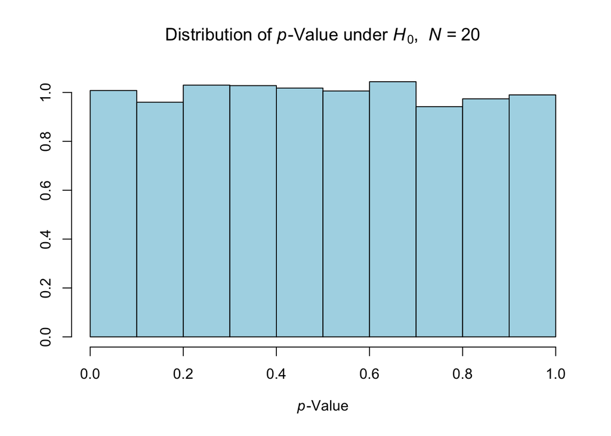

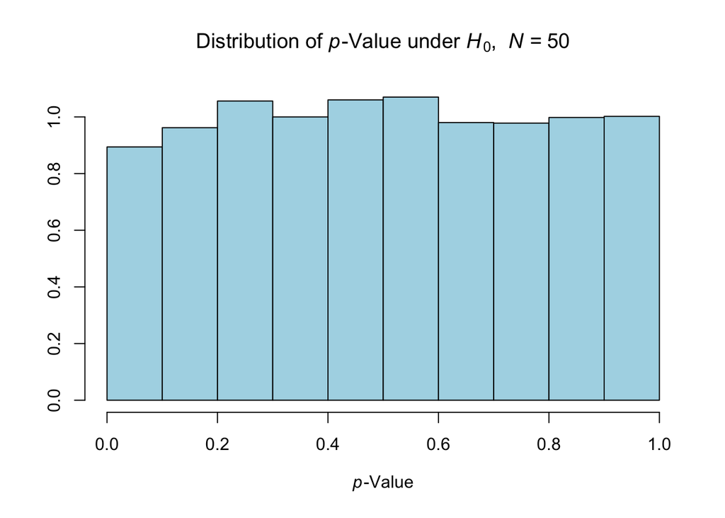

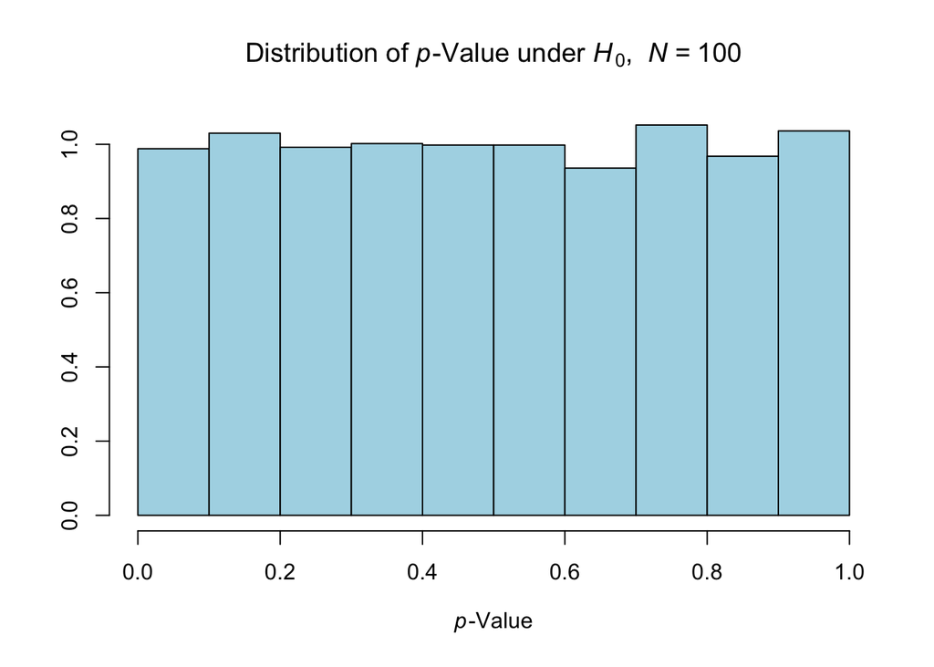

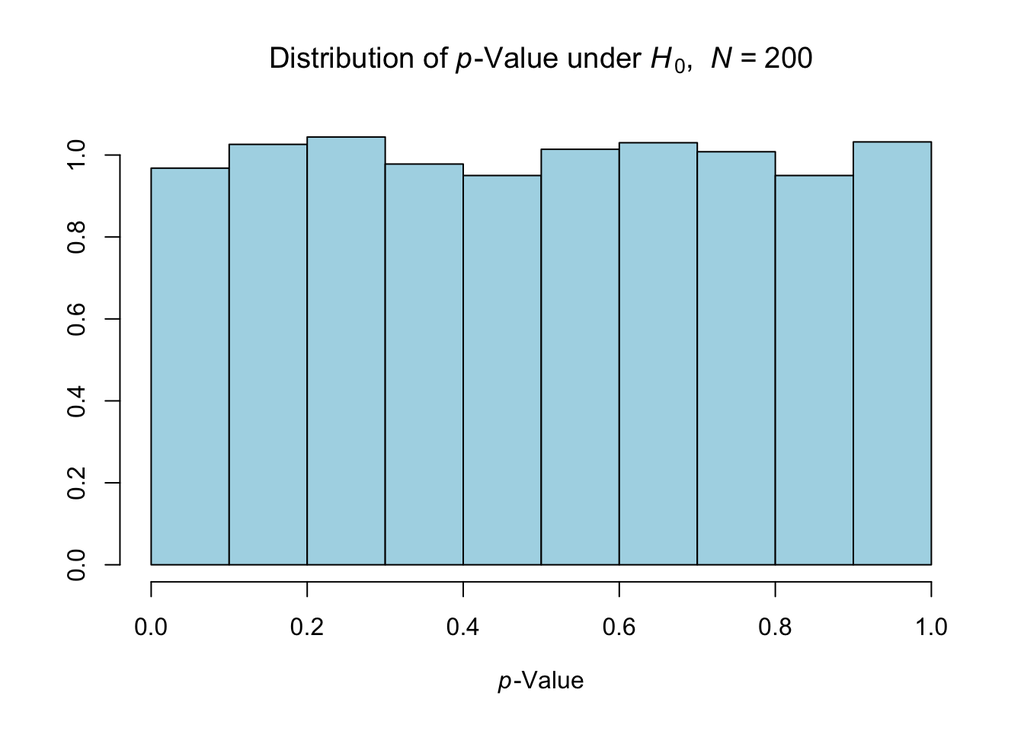

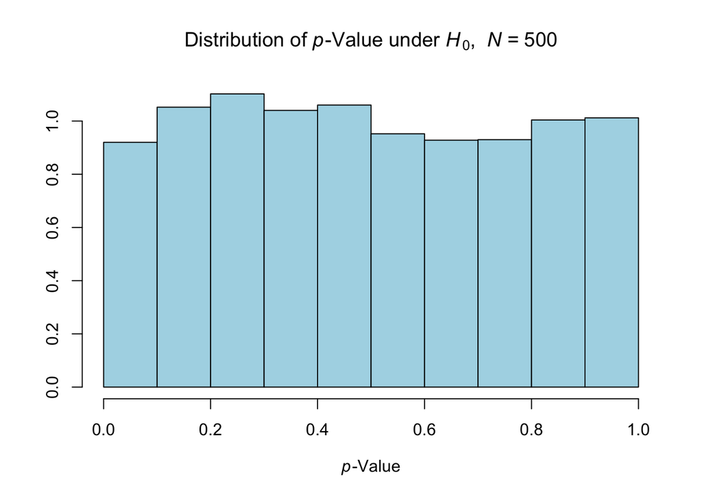

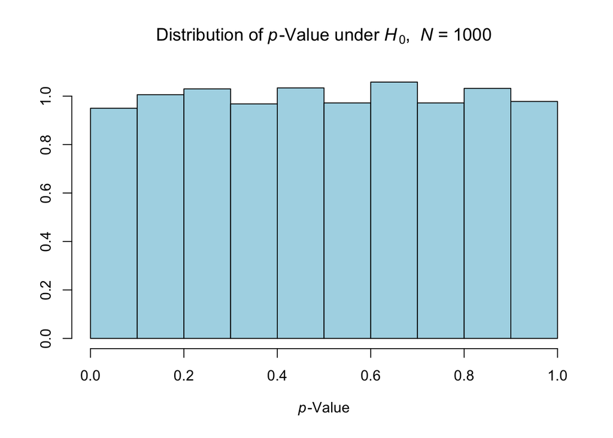

```r
for (i in 1:length(n)) {
  hist(pMat1[,i], prob=T, main=bquote("Distribution of " * italic("p") * "-Value under "
                                      * italic("H")[0] * ",  " * italic("N = ") * .(2*n[i])),
       xlab=expression(italic(p) * "-Value"), ylab="", col="lightblue")
  cat("<br><br>")
} # create the histograms
```

The regularity condition **R1** appears to hold for the $t$-test.

scroll to top

#### **R2**

We set the model parameters to $\sigma_1=\sigma_2=\sigma=1$, $\mu_1=0$, and $\mu_2=0.5$, so that $\mathcal{H}_1:\theta=\mu_1-\mu_2\neq0$ is true.

Cohen’s $d=\frac{\lvert\mu_2-\mu_1\rvert}{\sigma}=0.5$ indicates a medium effect size.

```r
set.seed(277)
distMat1 <- sapply(n, function(x) replicate(nSim, computeDist1(x)$D)) # roughly 1.8 seconds of run time
```

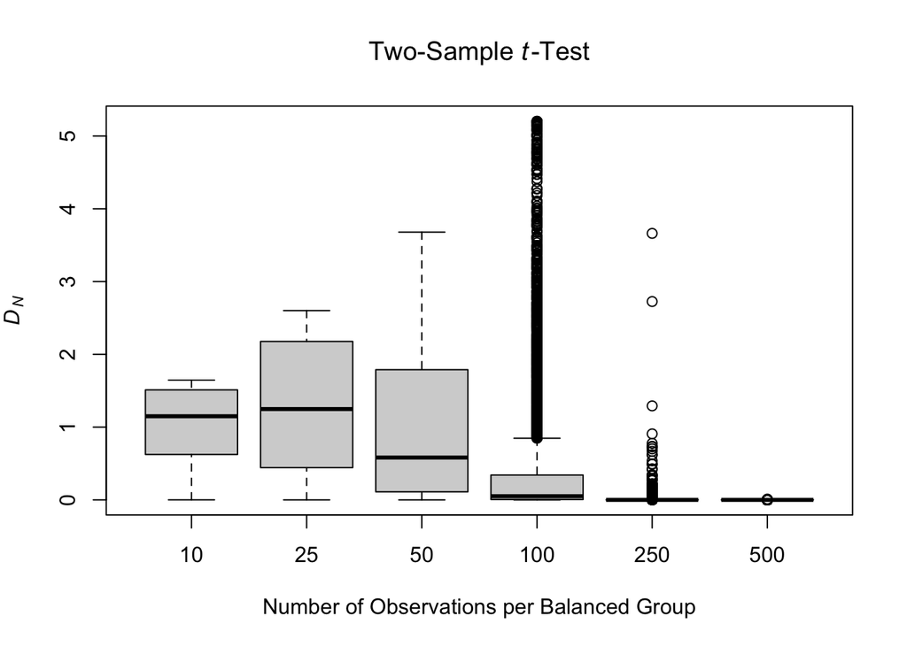

```r
boxplot(distMat1, names=n, ylab=expression(italic(D)[italic(N)]),
        xlab="Number of Observations per Balanced Group",
        main=expression("Two-Sample " * italic(t) * "-Test")) # create the boxplot
```

The regularity condition **R2** appears to hold for the $t$-test.

scroll to top

#### Local Alternative

We simulate under $\mathcal{H}_1:\theta^*=\theta_0+\frac{c}{n^\kappa}$ for $\kappa\in\{0.5,\ 0.25\}$.

```r
set.seed(277)
distAlt1b <- sapply(n*100, function(x) replicate(nSim, computeDist1(x, loc.alt=T)$D))

set.seed(277)
distAlt1c <- sapply(n*100, function(x) replicate(nSim, computeDist1(x, loc.alt=T, kappa=0.25)$D))
```

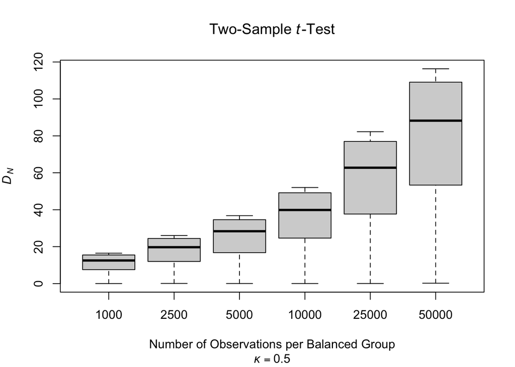

```r
boxplot(distAlt1b, names=n*100, ylab=expression(italic(D)[italic(N)]),
        xlab="Number of Observations per Balanced Group",
        main=expression("Two-Sample " * italic(t) * "-Test"),
        sub=expression(italic(κ)==0.5))
```

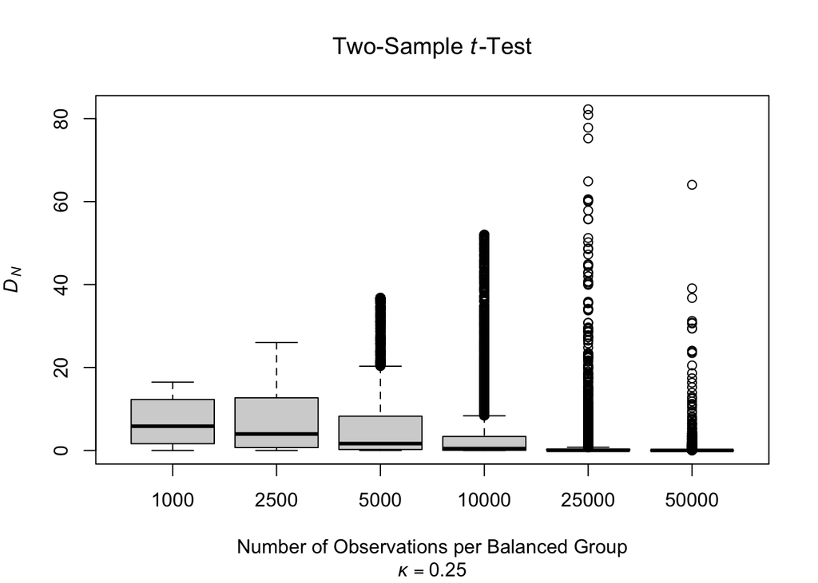

```r
boxplot(distAlt1c, names=n*100, ylab=expression(italic(D)[italic(N)]),
        xlab="Number of Observations per Balanced Group",
        main=expression("Two-Sample " * italic(t) * "-Test"),
        sub=expression(italic(κ)==0.25))
```

The regularity condition **R2** does not appear to hold for the $t$-test under the local alternative ($\kappa=0.5$). When sample size is extremely large and $\kappa=0.25$, **R2** shrinks to zero.

scroll to top

### Linear Regression

In this case, we assume
$$\begin{equation}
y_i=\beta_0+\beta_1
x_i+\epsilon_i,\quad\epsilon_i\overset{\text{i.i.d.}}{\sim}\mathcal{N}(0,\
\sigma_\epsilon^2)\quad\text{for}\ i=1,\dotsb,N.
\end{equation}$$

The sample size $N$ is the total number of observations. The degree of freedom is $q=1$.

#### **R1**

We set the model parameters to $\beta_0=1$, $\beta_1=0$, and $\sigma_\epsilon=1$. The test is two-sided with null hypothesis $\mathcal{H}_0:\beta_1=0$.

```r
nSim <- 5000 # number of simulation runs for each setting
N <- c(10, 25, 50, 100, 250, 500) # numbers of observations
```

```r
computeDist2 <- function(N, intercept=1, slope=0.5, sigma=1) {
  #' Input -
  #' N:              number of observations
  #' intercept:      true baseline at x = 0
  #' slope:          true regression coefficient
  #' sigma:          true error standard deviation
  #'
  #' Output -
  #' a list of the p-value and $D_{N}=\sqrt{N}\cdot p\cdot(-\ln{p})$ in Eq. 7

  x <- stats::rnorm(N) # independent variable
  y <- intercept + slope * x + stats::rnorm(N, 0, sigma) # dependent variable
  pVal <- summary(stats::lm(y ~ x))$coefficients["x", "Pr(>|t|)"] # p-value of the regression coefficient
  list("p"=pVal,
       "D"=sqrt(N) * pVal * -log(pVal) )
}

set.seed(277)
pMat2 <- sapply(N, function(x) replicate(nSim, computeDist2(x, slope=0)$p)) # roughly 7.8 seconds of run time
```

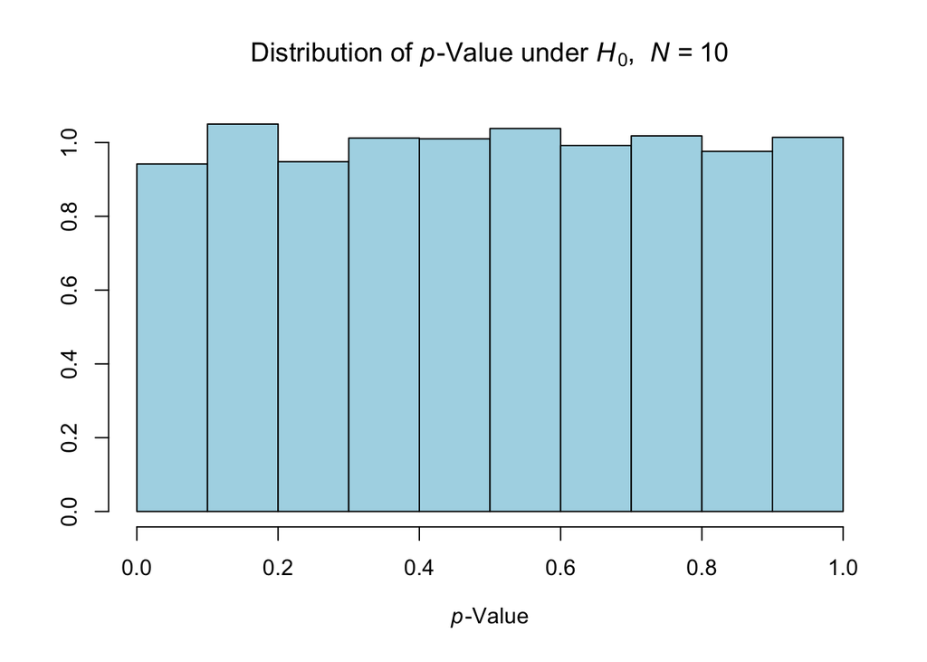

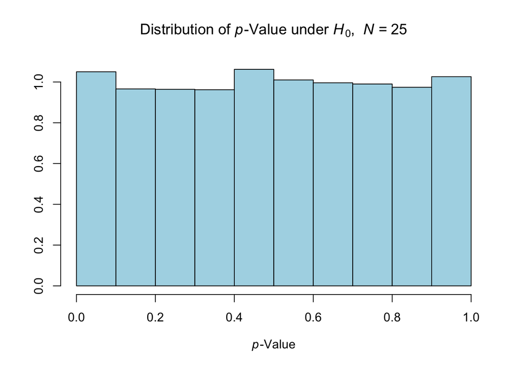

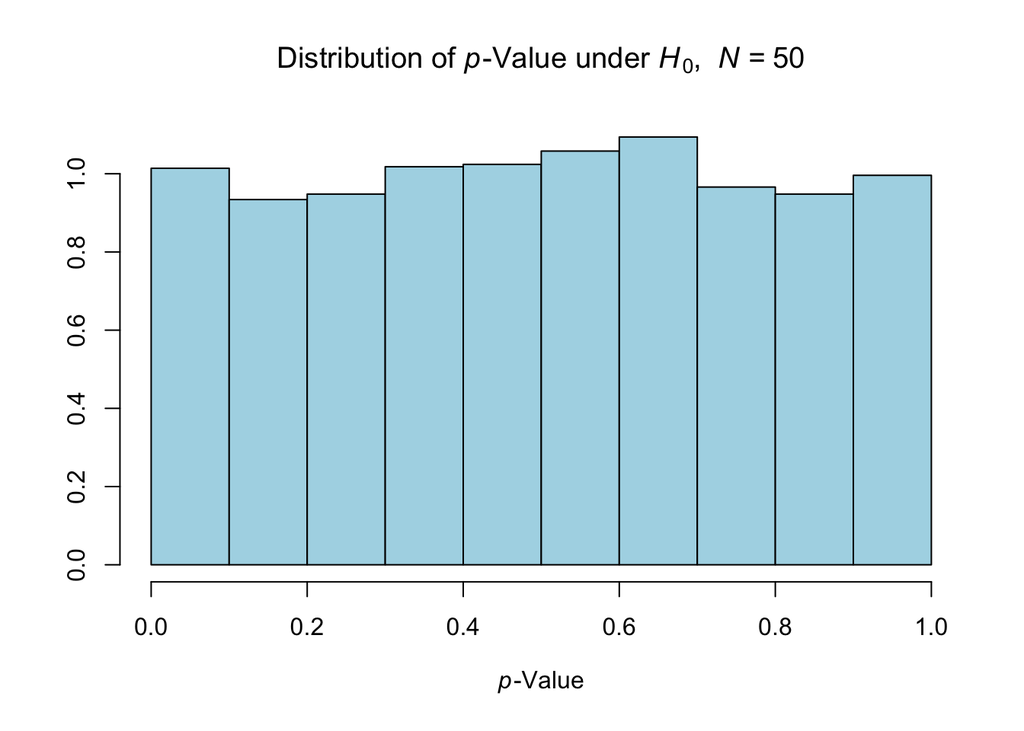

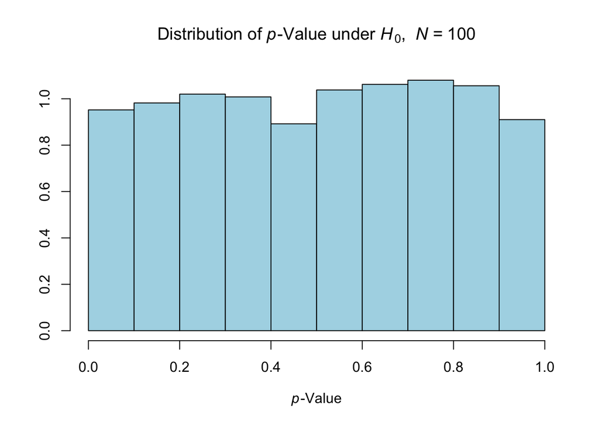

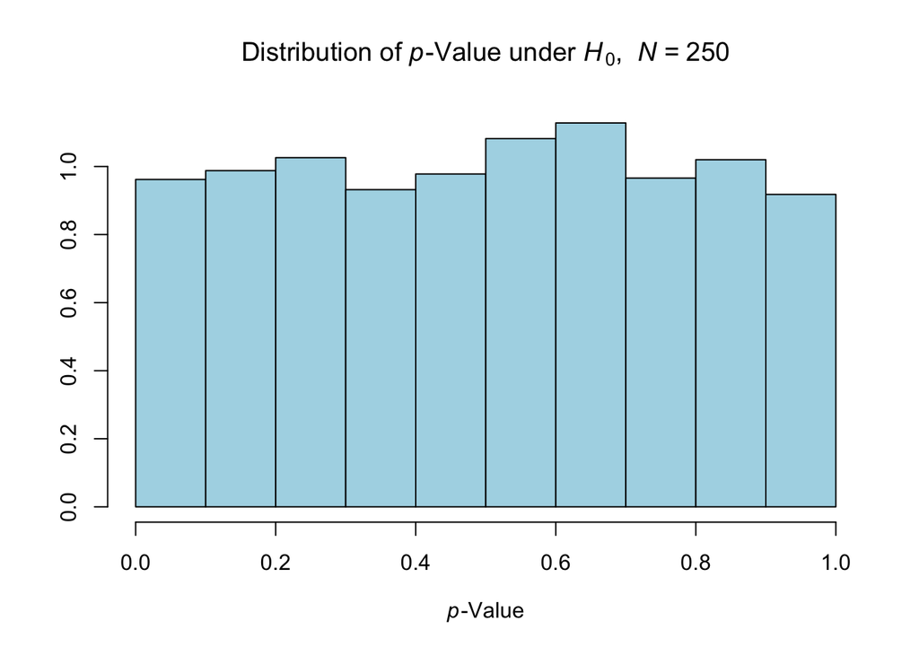

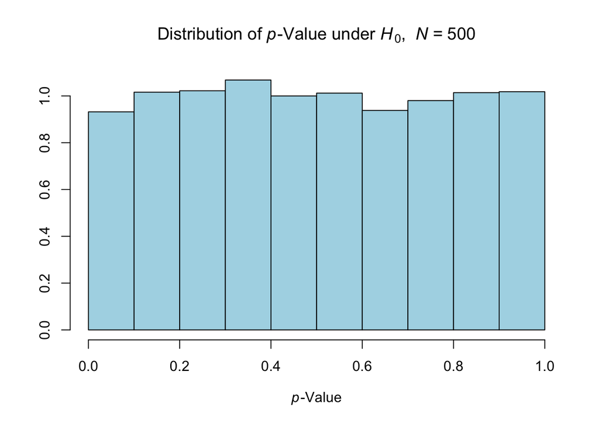

```r
for (i in 1:length(N)) {
  hist(pMat2[,i], prob=T, main=bquote("Distribution of " * italic("p") * "-Value under "
                                      * italic("H")[0] * ",  " * italic("N = ") * .(N[i])),
       xlab=expression(italic(p) * "-Value"), ylab="", col="lightblue")
  cat("<br><br>")
} # create the histograms
```

The regularity condition **R1** appears to hold for linear regression.

scroll to top

#### **R2**

We set the model parameters to $\beta_0=1$, $\beta_1=0.5$, and $\sigma_\epsilon=1$.

```r
set.seed(277)
distMat2 <- sapply(N, function(x) replicate(nSim, computeDist2(x)$D)) # roughly 7.3 seconds of run time
```

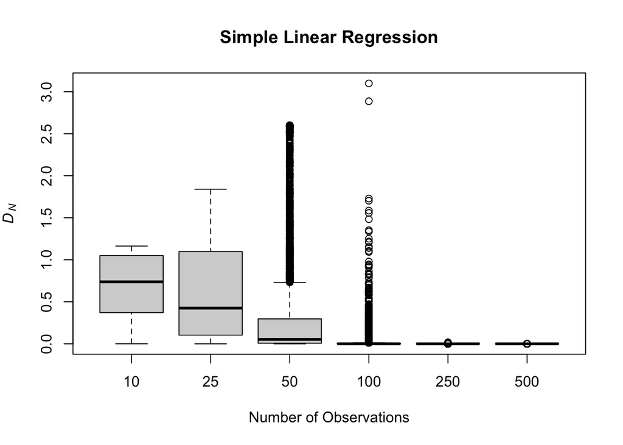

```r
boxplot(distMat2, names=N, ylab=expression(italic(D)[italic(N)]), xlab="Number of Observations",
        main="Simple Linear Regression") # create the boxplot
```

The regularity condition **R2** appears to hold for linear regression.

scroll to top

### Logistic Regression

In this case, we assume
$$\begin{align}
y_i&\overset{\text{i.i.d.}}{\sim}\operatorname{Bin}(10,\ p_i) \\
&\ln{\frac{p_i}{1-p_i}}=\beta_0+\beta_1 x_i\quad\text{for}\
i=1,\dotsb,N.
\end{align}$$

The sample size $N$ is the total number of observations. The degree of freedom is $q=1$.

#### **R1**

We set the model parameters to $\beta_0=0$ and $\beta_1=0$. The test is two-sided with null hypothesis $\mathcal{H}_0:\beta_1=0$.

```r
nSim <- 5000 # number of simulation runs for each setting
N <- c(10, 25, 50, 100, 250, 500) # numbers of observations
```

```r
computeDist3 <- function(N, size=10, intercept=0, slope=0.5) {
  #' Input -
  #' N:              number of observations
  #' size:           number of trials
  #' intercept:      true intercept
  #' slope:          true coefficient
  #'
  #' Output -
  #' a list of the p-value and $D_{N}=\sqrt{N}\cdot p\cdot(-\ln{p})$ in Eq. 7

  x <- stats::rnorm(N) # predictor variable
  p <- 1 / (1 + exp(-intercept - slope * x)) # success probability
  y <- stats::rbinom(N, size, p) # outcome variable
  pVal <- summary(stats::glm(cbind(y, size-y) ~ x, family=binomial))$coefficients["x", "Pr(>|z|)"]
  list("p"=pVal,
       "D"=sqrt(N) * pVal * -log(pVal) )
}

set.seed(277)
pMat3 <- sapply(N, function(x) replicate(nSim, computeDist3(x, slope=0)$p)) # roughly 16 seconds of run time
```

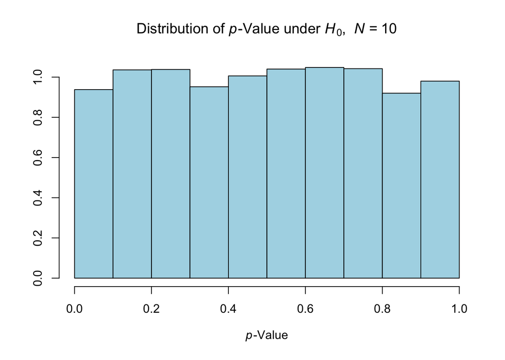

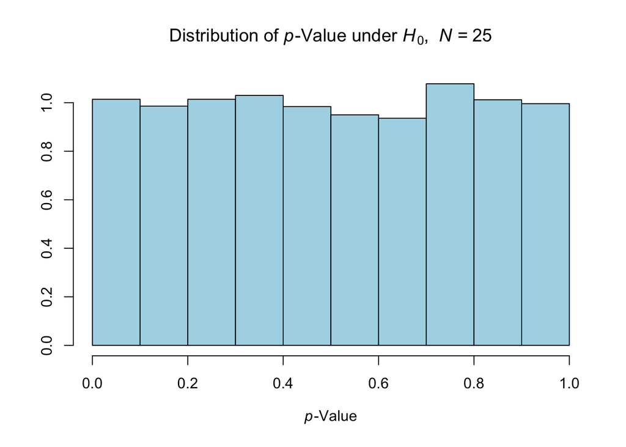

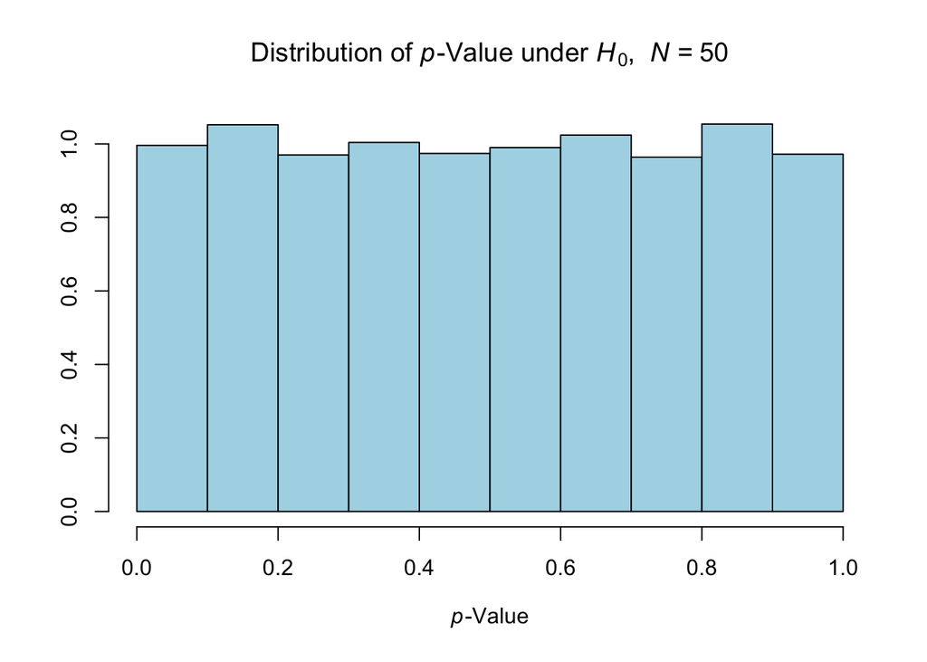

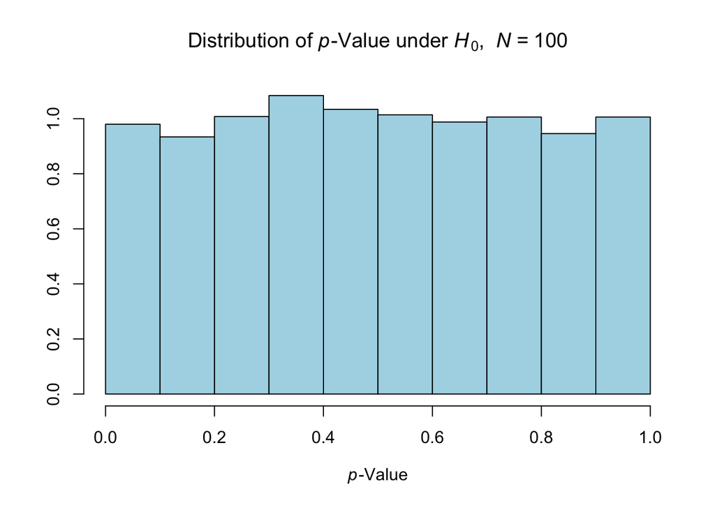

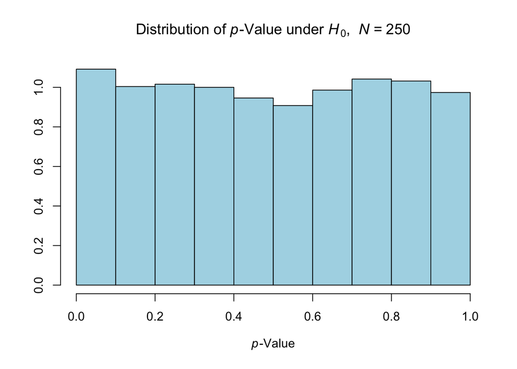

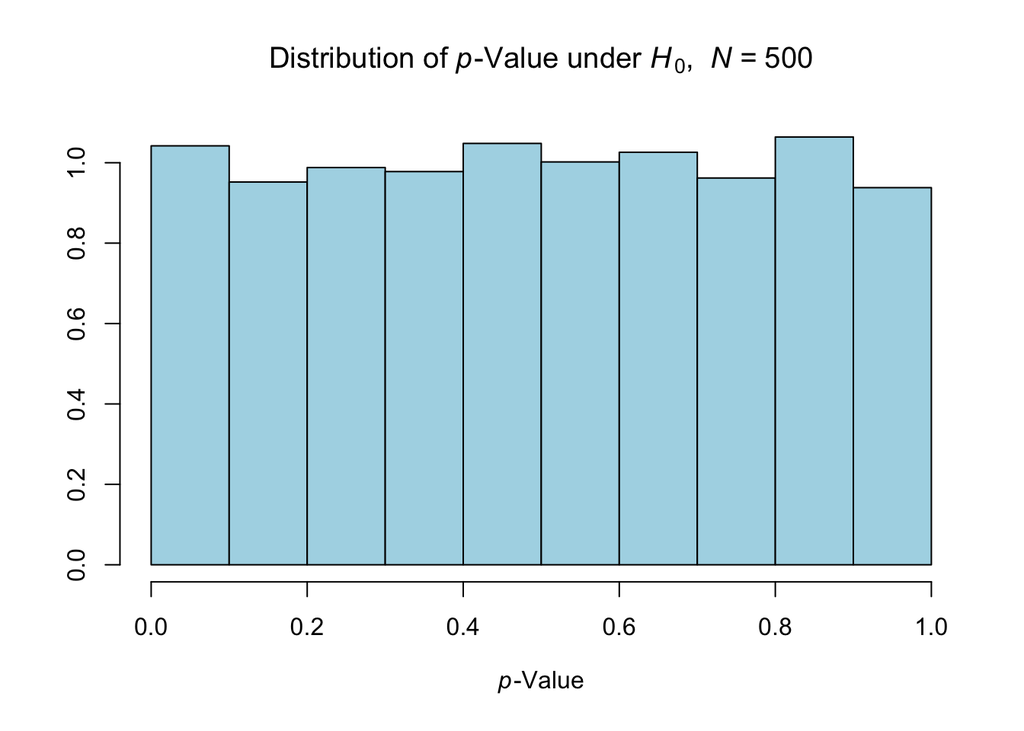

```r
for (i in 1:length(N)) {
  hist(pMat3[,i], prob=T, main=bquote("Distribution of " * italic("p") * "-Value under "
                                      * italic("H")[0] * ",  " * italic("N = ") * .(N[i])),
       xlab=expression(italic(p) * "-Value"), ylab="", col="lightblue")
  cat("<br><br>")
} # create the histograms
```

The regularity condition **R1** appears to hold for logistic regression.

scroll to top

#### **R2**

We set the model parameters to $\beta_0=0$ and $\beta_1=0.5$. The odds ratio is $e^{\beta_1}\approx1.65$.

```r
set.seed(277)
distMat3 <- sapply(N, function(x) replicate(nSim, computeDist3(x)$D)) # roughly 17 seconds of run time
```

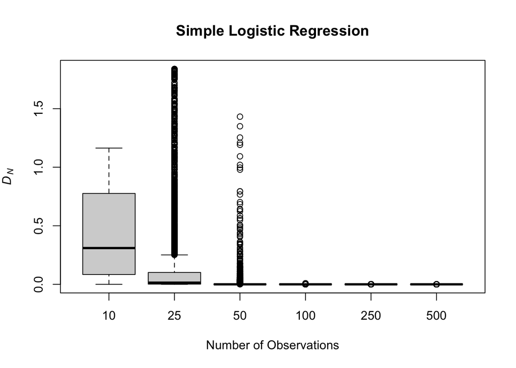

```r
boxplot(distMat3, names=N, ylab=expression(italic(D)[italic(N)]), xlab="Number of Observations",
        main="Simple Logistic Regression") # create the boxplot
```

The regularity condition **R2** appears to hold for logistic regression.

scroll to top

### ANOVA

Let’s assume a balanced one-way design with $I$ levels, where $Y_{ij}$ denotes the response obtained from the $j$-th subject in group $i$.
$$\begin{equation}
Y_{ij}=\mu+\alpha_i+\epsilon_{ij},\quad\epsilon_{ij}\overset{\text{i.i.d.}}{\sim}\mathcal{N}(0,\
\sigma_\epsilon^2)\quad\text{for}\ i=1,\dotsb,I\ \text{and}\
j=1,\dotsb,n.
\end{equation}$$

The sample size $N=nI$ is the total number of observations. The degrees of freedom are $q=I-1$.

#### **R1**

We set the model parameters to $I=4$, $\mu=2$, $\alpha_1=\alpha_2=\alpha_3=\alpha_4=0$, and $\sigma_\epsilon=1$.

$\mu_i=\mu+\alpha_i$ and $\mu_0=\frac{1}{I}\sum_{i=1}^I\mu_i$

$\mathcal{H}_0:\boldsymbol{\theta}=(\mu_1-\mu_0,\ \mu_2-\mu_0,\ \mu_3-\mu_0)^\top=\boldsymbol{0}$

```r
nSim <- 5000 # number of simulation runs for each setting
n <- c(10, 25, 50, 100, 250, 500) # numbers of observations per balanced group
```

```r
computeDist4 <- function(n, m1=2, m2=2, m3=2.25, m4=2.5, sigma=1) {
  #' Input -
  #' n:              number of observations per balanced group
  #' m1:             population mean for the first group
  #' m2:             population mean for the second group
  #' m3:             population mean for the third group
  #' m4:             population mean for the fourth group
  #' sigma:          true error standard deviation
  #'
  #' Output -
  #' a list of the p-value and $D_{N}=\sqrt{N}\cdot p\cdot(-\ln{p})$ in Eq. 7

  y <- stats::rnorm(n * 4, c(m1, m2, m3, m4), sigma) # responses
  pVal <- summary(stats::aov(y ~ factor(rep(1:4, n))))[[1]][1, "Pr(>F)"] # p-value in one-way ANOVA
  list("p"=pVal,
       "D"=sqrt(n * 4) * pVal * -log(pVal) ) # use total number of observations
}

set.seed(277)
pMat4 <- sapply(n, function(x) replicate(nSim, computeDist4(x, m3=2, m4=2)$p)) # roughly 14 seconds of run time
```

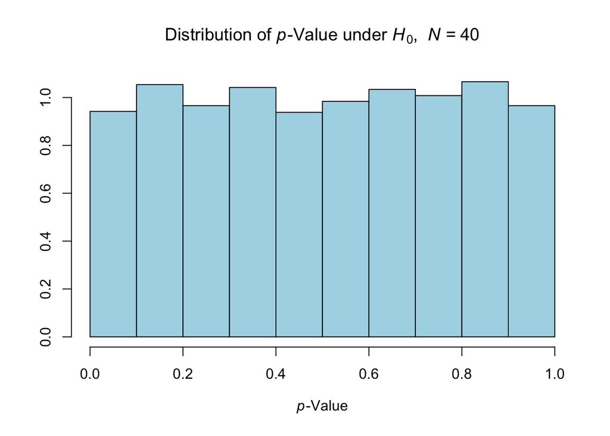

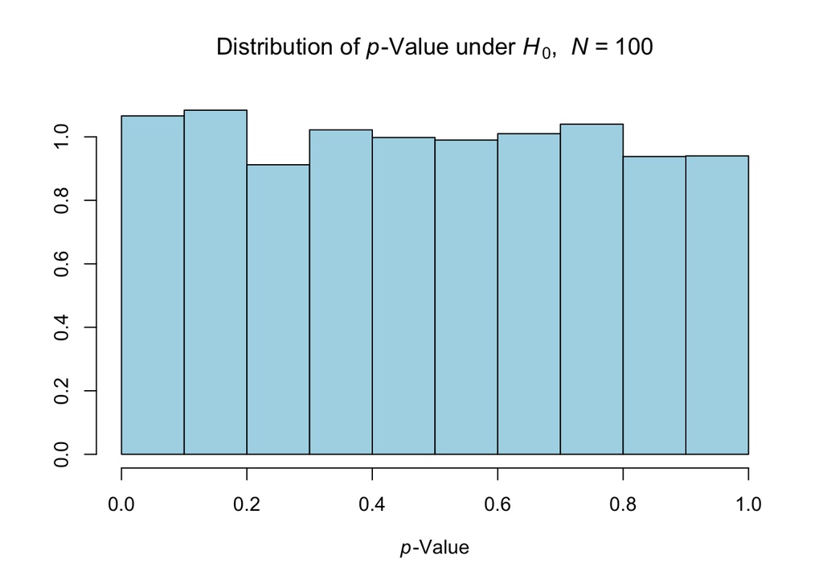

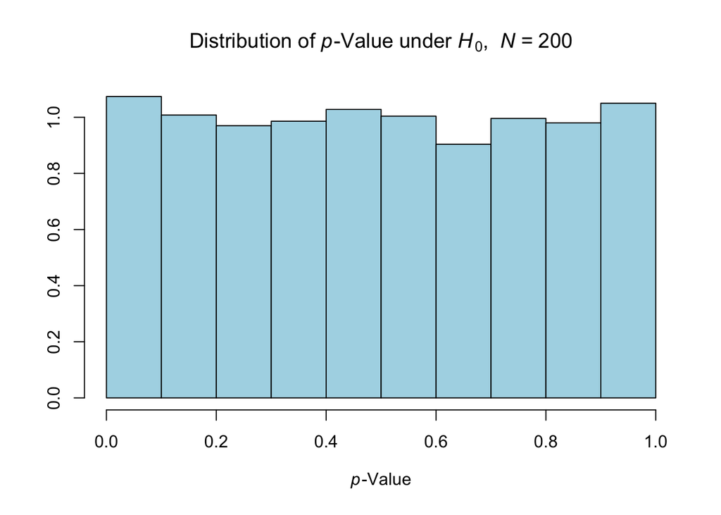

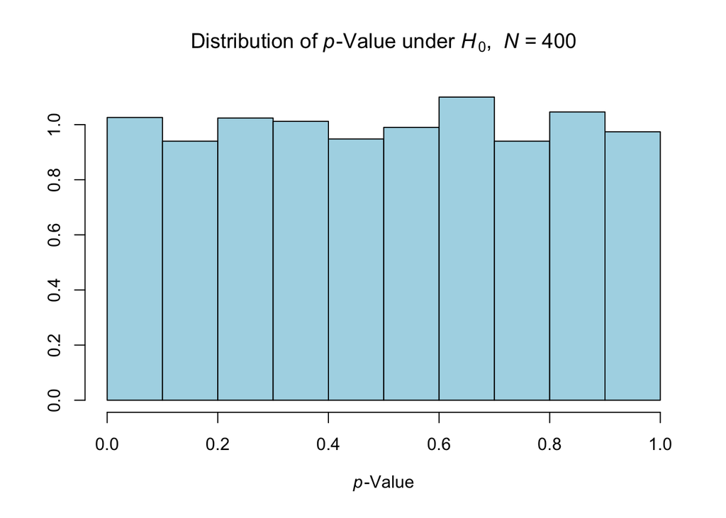

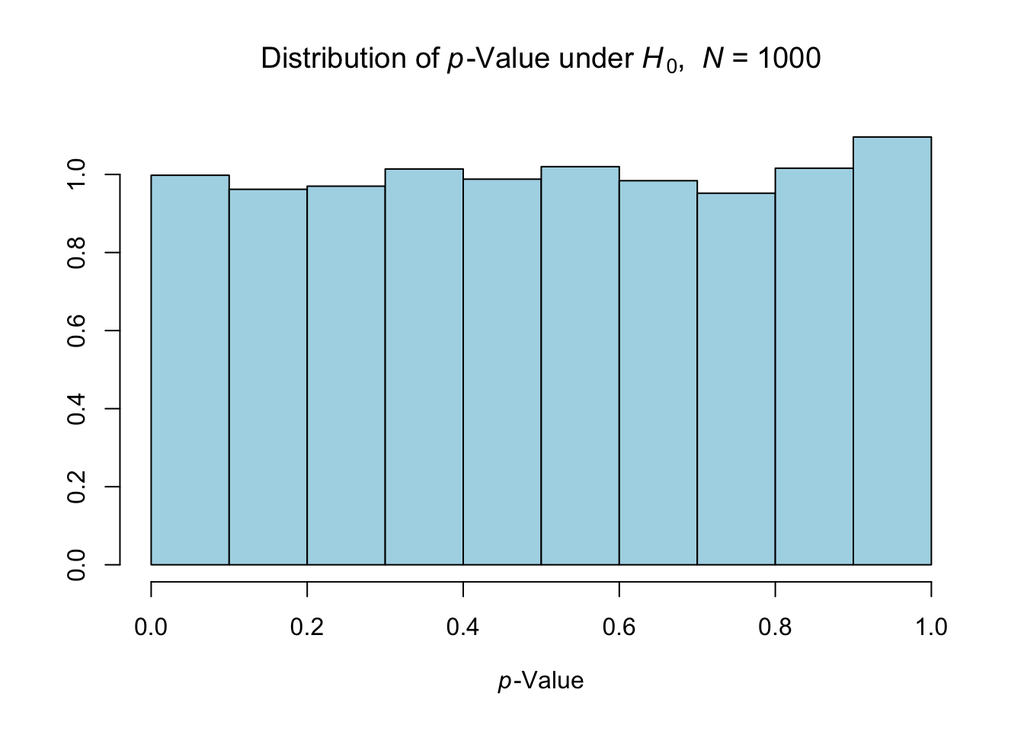

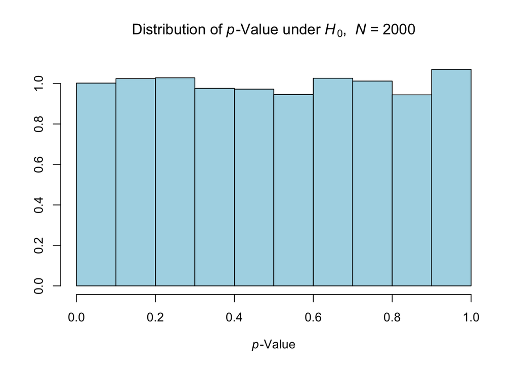

```r
for (i in 1:length(n)) {
  hist(pMat4[,i], prob=T, main=bquote("Distribution of " * italic("p") * "-Value under "
                                      * italic("H")[0] * ",  " * italic("N = ") * .(4*n[i])),
       xlab=expression(italic(p) * "-Value"), ylab="", col="lightblue")
  cat("<br><br>")
} # create the histograms
```

The regularity condition **R1** appears to hold for one-way ANOVA.

scroll to top

#### **R2**

We set the model parameters to $I=4$, $\mu=2$, $\alpha_1=0$, $\alpha_2=0$, $\alpha_3=0.25$, $\alpha_4=0.5$, and $\sigma_\epsilon=1$.

$\mu_i=\mu+\alpha_i$ and $\mu_0=\frac{1}{I}\sum_{i=1}^I\mu_i$

$\mathcal{H}_1:\boldsymbol{\theta}=(\mu_1-\mu_0,\ \mu_2-\mu_0,\ \mu_3-\mu_0)^\top\neq\boldsymbol{0}$

```r
set.seed(277)
distMat4 <- sapply(n, function(x) replicate(nSim, computeDist4(x)$D)) # roughly 14 seconds of run time
```

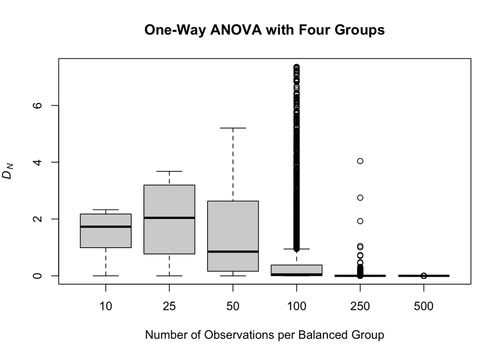

```r
boxplot(distMat4, names=n, ylab=expression(italic(D)[italic(N)]),
        xlab="Number of Observations per Balanced Group",
        main="One-Way ANOVA with Four Groups") # create the boxplot
```

The regularity condition **R2** appears to hold for one-way ANOVA.

scroll to top

### Repeated-Measures ANOVA

Let’s assume a single factor within-subject design with $I$ levels of the within-subject factor measured on each subject. Let $Y_{ij}$ denote the response collected at the $i$-th level of the within-subject factor for subject $j$.
$$\begin{equation}
Y_{ij}=\mu+\alpha_i+s_j+\epsilon_{ij},\quad
s_{j}\overset{\text{i.i.d.}}{\sim}\mathcal{N}(0,\ \sigma_s^2)\ \perp
\!\!\! \perp\ \epsilon_{ij}\overset{\text{i.i.d.}}{\sim}\mathcal{N}(0,\
\sigma_\epsilon^2)\quad\text{for}\ i=1,\dotsb,I\ \text{and}\
j=1,\dotsb,n.
\end{equation}$$

The sample size $N=n(I-1)$ is the number of independent observations. The degrees of freedom are $q=I-1$.